# Optimal Treatment Analysis

## Outcome Variable

**Outcome Variable:** haz

## Predictor Variables

**Intervention Variable:** hhwealth_quart

**Adjustment Set:**

- arm
- sex
- W_mage
- meducyrs
- feducyrs
- W_gagebrth
- W_birthwt
- W_birthlen
- W_nchldlt5
- W_parity
- delta_W_mage
- delta_meducyrs
- delta_feducyrs
- delta_W_gagebrth
- delta_W_birthwt
- delta_W_birthlen
- delta_W_nchldlt5
- delta_W_parity

## Stratifying Variables

The analysis was stratified on these variable(s):

- agecat
- studyid
- country

## Data Summary

| agecat | studyid | country | hhwealth_quart | n_cell | n |
| --- | --- | --- | --- | --- | --- |
| Birth | ki0047075b-MAL-ED | BANGLADESH | Wealth Q4 | 56 | 213 |
| Birth | ki0047075b-MAL-ED | BANGLADESH | Wealth Q1 | 52 | 213 |
| Birth | ki0047075b-MAL-ED | BANGLADESH | Wealth Q2 | 51 | 213 |
| Birth | ki0047075b-MAL-ED | BANGLADESH | Wealth Q3 | 54 | 213 |
| Birth | ki0047075b-MAL-ED | BRAZIL | Wealth Q4 | 11 | 60 |
| Birth | ki0047075b-MAL-ED | BRAZIL | Wealth Q1 | 21 | 60 |
| Birth | ki0047075b-MAL-ED | BRAZIL | Wealth Q2 | 17 | 60 |
| Birth | ki0047075b-MAL-ED | BRAZIL | Wealth Q3 | 11 | 60 |
| Birth | ki0047075b-MAL-ED | INDIA | Wealth Q4 | 8 | 41 |
| Birth | ki0047075b-MAL-ED | INDIA | Wealth Q1 | 14 | 41 |
| Birth | ki0047075b-MAL-ED | INDIA | Wealth Q2 | 9 | 41 |
| Birth | ki0047075b-MAL-ED | INDIA | Wealth Q3 | 10 | 41 |
| Birth | ki0047075b-MAL-ED | NEPAL | Wealth Q4 | 6 | 26 |
| Birth | ki0047075b-MAL-ED | NEPAL | Wealth Q1 | 9 | 26 |
| Birth | ki0047075b-MAL-ED | NEPAL | Wealth Q2 | 3 | 26 |
| Birth | ki0047075b-MAL-ED | NEPAL | Wealth Q3 | 8 | 26 |
| Birth | ki0047075b-MAL-ED | PERU | Wealth Q4 | 54 | 215 |
| Birth | ki0047075b-MAL-ED | PERU | Wealth Q1 | 55 | 215 |
| Birth | ki0047075b-MAL-ED | PERU | Wealth Q2 | 54 | 215 |
| Birth | ki0047075b-MAL-ED | PERU | Wealth Q3 | 52 | 215 |
| Birth | ki0047075b-MAL-ED | SOUTH AFRICA | Wealth Q4 | 17 | 96 |
| Birth | ki0047075b-MAL-ED | SOUTH AFRICA | Wealth Q1 | 27 | 96 |
| Birth | ki0047075b-MAL-ED | SOUTH AFRICA | Wealth Q2 | 24 | 96 |
| Birth | ki0047075b-MAL-ED | SOUTH AFRICA | Wealth Q3 | 28 | 96 |
| Birth | ki0047075b-MAL-ED | TANZANIA, UNITED REPUBLIC OF | Wealth Q4 | 26 | 120 |
| Birth | ki0047075b-MAL-ED | TANZANIA, UNITED REPUBLIC OF | Wealth Q1 | 28 | 120 |
| Birth | ki0047075b-MAL-ED | TANZANIA, UNITED REPUBLIC OF | Wealth Q2 | 32 | 120 |
| Birth | ki0047075b-MAL-ED | TANZANIA, UNITED REPUBLIC OF | Wealth Q3 | 34 | 120 |
| Birth | ki1000108-CMC-V-BCS-2002 | INDIA | Wealth Q4 | 32 | 92 |
| Birth | ki1000108-CMC-V-BCS-2002 | INDIA | Wealth Q1 | 15 | 92 |

[output cut: 178 more lines]

The following strata were considered:

- agecat: 24 months, studyid: ki0047075b-MAL-ED, country: BANGLADESH
- agecat: 24 months, studyid: ki0047075b-MAL-ED, country: BRAZIL
- agecat: 24 months, studyid: ki0047075b-MAL-ED, country: INDIA
- agecat: 24 months, studyid: ki0047075b-MAL-ED, country: NEPAL
- agecat: 24 months, studyid: ki0047075b-MAL-ED, country: PERU
- agecat: 24 months, studyid: ki0047075b-MAL-ED, country: SOUTH AFRICA
- agecat: 24 months, studyid: ki0047075b-MAL-ED, country: TANZANIA, UNITED REPUBLIC OF
- agecat: 24 months, studyid: ki1000108-CMC-V-BCS-2002, country: INDIA
- agecat: 24 months, studyid: ki1000108-IRC, country: INDIA
- agecat: 24 months, studyid: ki1017093b-PROVIDE, country: BANGLADESH
- agecat: 24 months, studyid: ki1066203-TanzaniaChild2, country: TANZANIA, UNITED REPUBLIC OF
- agecat: 24 months, studyid: ki1113344-GMS-Nepal, country: NEPAL
- agecat: 24 months, studyid: ki1114097-CONTENT, country: PERU
- agecat: 24 months, studyid: ki1135781-COHORTS, country: GUATEMALA
- agecat: 24 months, studyid: ki1135781-COHORTS, country: PHILIPPINES
- agecat: 24 months, studyid: ki1148112-LCNI-5, country: MALAWI
- agecat: 24 months, studyid: kiGH5241-JiVitA-3, country: BANGLADESH
- agecat: 24 months, studyid: kiGH5241-JiVitA-4, country: BANGLADESH
- agecat: 6 months, studyid: ki0047075b-MAL-ED, country: BANGLADESH
- agecat: 6 months, studyid: ki0047075b-MAL-ED, country: BRAZIL
- agecat: 6 months, studyid: ki0047075b-MAL-ED, country: INDIA
- agecat: 6 months, studyid: ki0047075b-MAL-ED, country: NEPAL
- agecat: 6 months, studyid: ki0047075b-MAL-ED, country: PERU
- agecat: 6 months, studyid: ki0047075b-MAL-ED, country: SOUTH AFRICA
- agecat: 6 months, studyid: ki0047075b-MAL-ED, country: TANZANIA, UNITED REPUBLIC OF
- agecat: 6 months, studyid: ki1000108-CMC-V-BCS-2002, country: INDIA
- agecat: 6 months, studyid: ki1000108-IRC, country: INDIA
- agecat: 6 months, studyid: ki1017093b-PROVIDE, country: BANGLADESH
- agecat: 6 months, studyid: ki1066203-TanzaniaChild2, country: TANZANIA, UNITED REPUBLIC OF
- agecat: 6 months, studyid: ki1113344-GMS-Nepal, country: NEPAL
- agecat: 6 months, studyid: ki1114097-CONTENT, country: PERU
- agecat: 6 months, studyid: ki1135781-COHORTS, country: GUATEMALA
- agecat: 6 months, studyid: ki1135781-COHORTS, country: PHILIPPINES
- agecat: 6 months, studyid: ki1148112-LCNI-5, country: MALAWI
- agecat: 6 months, studyid: kiGH5241-JiVitA-3, country: BANGLADESH
- agecat: 6 months, studyid: kiGH5241-JiVitA-4, country: BANGLADESH
- agecat: Birth, studyid: ki0047075b-MAL-ED, country: BANGLADESH
- agecat: Birth, studyid: ki0047075b-MAL-ED, country: BRAZIL
- agecat: Birth, studyid: ki0047075b-MAL-ED, country: INDIA
- agecat: Birth, studyid: ki0047075b-MAL-ED, country: NEPAL
- agecat: Birth, studyid: ki0047075b-MAL-ED, country: PERU
- agecat: Birth, studyid: ki0047075b-MAL-ED, country: SOUTH AFRICA
- agecat: Birth, studyid: ki0047075b-MAL-ED, country: TANZANIA, UNITED REPUBLIC OF
- agecat: Birth, studyid: ki1000108-CMC-V-BCS-2002, country: INDIA
- agecat: Birth, studyid: ki1000108-IRC, country: INDIA
- agecat: Birth, studyid: ki1017093b-PROVIDE, country: BANGLADESH
- agecat: Birth, studyid: ki1113344-GMS-Nepal, country: NEPAL
- agecat: Birth, studyid: ki1114097-CONTENT, country: PERU
- agecat: Birth, studyid: ki1135781-COHORTS, country: GUATEMALA
- agecat: Birth, studyid: ki1135781-COHORTS, country: PHILIPPINES
- agecat: Birth, studyid: kiGH5241-JiVitA-3, country: BANGLADESH
- agecat: Birth, studyid: kiGH5241-JiVitA-4, country: BANGLADESH

### Dropped Strata

Some strata were dropped due to rare outcomes:

- agecat: Birth, studyid: ki0047075b-MAL-ED, country: NEPAL
- agecat: Birth, studyid: ki1114097-CONTENT, country: PERU
- agecat: 24 months, studyid: ki1066203-TanzaniaChild2, country: TANZANIA, UNITED REPUBLIC OF

## Methods Detail

We’re interested in the causal parameters $E[Y_a]$ for all values of $a \in \mathcal{A}$. These parameters represent the mean outcome if, possibly contrary to fact, we intervened to set all units to have $A=a$. Under the randomization and positivity assumptions, these are identified by the statistical parameters $\psi_a=E_W[E_{Y|A,W}(Y|A=a,W)]$. In addition, we’re interested in the mean of $Y$, $E[Y]$ under no intervention (the observed mean). We will estimate these parameters by using SuperLearner to fit the relevant likelihood factors – $E_{Y|A,W}(Y|A=a,W)$ and $p(A=a|W)$, and then updating our likelihood fit using a joint TMLE.

For unadjusted analyses ($W=\{\}$), initial likelihoods were estimated using Lrnr_glm to estimate the simple $E(Y|A)$ and Lrnr_mean to estimate $p(A)$. For adjusted analyses, a small library containing Lrnr_glmnet, Lrnr_xgboost, and Lrnr_mean was used.

Having estimated these parameters, we will then use the delta method to estimate relative risks and attributable risks relative to a prespecified baseline level of $A$.

# Results Detail

## Results Plots

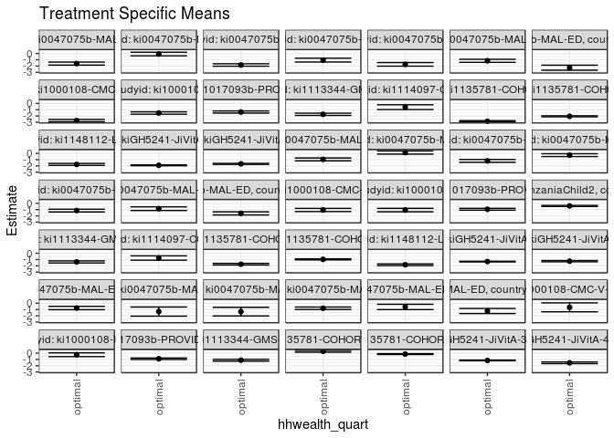

## Results Table

### Parameter: TSM

| agecat | studyid | country | intervention_level | baseline_level | estimate | ci_lower | ci_upper |
| --- | --- | --- | --- | --- | --- | --- | --- |
| Birth | ki0047075b-MAL-ED | BANGLADESH | optimal | observed | -0.7638036 | -1.0323708 | -0.4952365 |
| Birth | ki0047075b-MAL-ED | BRAZIL | optimal | observed | -1.3326919 | -2.0620137 | -0.6033701 |
| Birth | ki0047075b-MAL-ED | INDIA | optimal | observed | -1.3407657 | -2.0274341 | -0.6540973 |
| Birth | ki0047075b-MAL-ED | PERU | optimal | observed | -0.8028837 | -0.9990282 | -0.6067392 |
| Birth | ki0047075b-MAL-ED | SOUTH AFRICA | optimal | observed | -0.5935790 | -1.0192832 | -0.1678747 |
| Birth | ki0047075b-MAL-ED | TANZANIA, UNITED REPUBLIC OF | optimal | observed | -1.2383815 | -1.6424092 | -0.8343538 |
| Birth | ki1000108-CMC-V-BCS-2002 | INDIA | optimal | observed | -0.6553370 | -1.3675883 | 0.0569144 |
| Birth | ki1000108-IRC | INDIA | optimal | observed | -0.2506632 | -0.5519871 | 0.0506607 |
| Birth | ki1017093b-PROVIDE | BANGLADESH | optimal | observed | -0.8892342 | -1.0062185 | -0.7722499 |
| Birth | ki1113344-GMS-Nepal | NEPAL | optimal | observed | -1.1159517 | -1.2651991 | -0.9667044 |
| Birth | ki1135781-COHORTS | GUATEMALA | optimal | observed | 0.3114738 | 0.1636499 | 0.4592977 |
| Birth | ki1135781-COHORTS | PHILIPPINES | optimal | observed | -0.1433551 | -0.2137789 | -0.0729313 |
| Birth | kiGH5241-JiVitA-3 | BANGLADESH | optimal | observed | -1.1531186 | -1.2100946 | -1.0961425 |
| Birth | kiGH5241-JiVitA-4 | BANGLADESH | optimal | observed | -1.5370160 | -1.6682095 | -1.4058225 |
| 6 months | ki0047075b-MAL-ED | BANGLADESH | optimal | observed | -0.9603165 | -1.1875113 | -0.7331217 |
| 6 months | ki0047075b-MAL-ED | BRAZIL | optimal | observed | 0.1325892 | -0.1223217 | 0.3875001 |
| 6 months | ki0047075b-MAL-ED | INDIA | optimal | observed | -1.1949242 | -1.4223356 | -0.9675128 |
| 6 months | ki0047075b-MAL-ED | NEPAL | optimal | observed | -0.2805259 | -0.5020394 | -0.0590124 |
| 6 months | ki0047075b-MAL-ED | PERU | optimal | observed | -1.1510238 | -1.3728309 | -0.9292167 |
| 6 months | ki0047075b-MAL-ED | SOUTH AFRICA | optimal | observed | -0.8536654 | -1.1435058 | -0.5638250 |
| 6 months | ki0047075b-MAL-ED | TANZANIA, UNITED REPUBLIC OF | optimal | observed | -1.6009409 | -1.8487873 | -1.3530945 |
| 6 months | ki1000108-CMC-V-BCS-2002 | INDIA | optimal | observed | -1.0579014 | -1.3093096 | -0.8064932 |
| 6 months | ki1000108-IRC | INDIA | optimal | observed | -1.0718289 | -1.3429160 | -0.8007418 |
| 6 months | ki1017093b-PROVIDE | BANGLADESH | optimal | observed | -0.9475440 | -1.0958621 | -0.7992258 |
| 6 months | ki1066203-TanzaniaChild2 | TANZANIA, UNITED REPUBLIC OF | optimal | observed | -0.4186194 | -0.5046962 | -0.3325426 |
| 6 months | ki1113344-GMS-Nepal | NEPAL | optimal | observed | -1.3754867 | -1.5399758 | -1.2109977 |
| 6 months | ki1114097-CONTENT | PERU | optimal | observed | -0.7576263 | -1.1060979 | -0.4091548 |
| 6 months | ki1135781-COHORTS | GUATEMALA | optimal | observed | -1.7414096 | -1.8685772 | -1.6142420 |
| 6 months | ki1135781-COHORTS | PHILIPPINES | optimal | observed | -0.9676935 | -1.0500101 | -0.8853768 |
| 6 months | ki1148112-LCNI-5 | MALAWI | optimal | observed | -1.8306296 | -1.9666701 | -1.6945891 |
| 6 months | kiGH5241-JiVitA-3 | BANGLADESH | optimal | observed | -1.3227399 | -1.3753110 | -1.2701688 |
| 6 months | kiGH5241-JiVitA-4 | BANGLADESH | optimal | observed | -1.2611082 | -1.3564549 | -1.1657614 |
| 24 months | ki0047075b-MAL-ED | BANGLADESH | optimal | observed | -1.6090631 | -1.8482125 | -1.3699137 |
| 24 months | ki0047075b-MAL-ED | BRAZIL | optimal | observed | -0.0837198 | -0.3669994 | 0.1995597 |
| 24 months | ki0047075b-MAL-ED | INDIA | optimal | observed | -1.8340356 | -2.0268919 | -1.6411793 |
| 24 months | ki0047075b-MAL-ED | NEPAL | optimal | observed | -1.0558005 | -1.3621133 | -0.7494877 |
| 24 months | ki0047075b-MAL-ED | PERU | optimal | observed | -1.7293404 | -2.0178885 | -1.4407923 |
| 24 months | ki0047075b-MAL-ED | SOUTH AFRICA | optimal | observed | -1.1641011 | -1.4073303 | -0.9208719 |
| 24 months | ki0047075b-MAL-ED | TANZANIA, UNITED REPUBLIC OF | optimal | observed | -2.2647706 | -2.6648835 | -1.8646578 |
| 24 months | ki1000108-CMC-V-BCS-2002 | INDIA | optimal | observed | -2.7278002 | -2.9141125 | -2.5414878 |
| 24 months | ki1000108-IRC | INDIA | optimal | observed | -1.5278344 | -1.7204415 | -1.3352274 |
| 24 months | ki1017093b-PROVIDE | BANGLADESH | optimal | observed | -1.3701374 | -1.5392519 | -1.2010229 |
| 24 months | ki1113344-GMS-Nepal | NEPAL | optimal | observed | -1.7328145 | -1.9125466 | -1.5530824 |
| 24 months | ki1114097-CONTENT | PERU | optimal | observed | -0.5936832 | -0.9725244 | -0.2148421 |
| 24 months | ki1135781-COHORTS | GUATEMALA | optimal | observed | -2.8488716 | -2.9472127 | -2.7505304 |
| 24 months | ki1135781-COHORTS | PHILIPPINES | optimal | observed | -2.0541444 | -2.1373996 | -1.9708892 |
| 24 months | ki1148112-LCNI-5 | MALAWI | optimal | observed | -1.7569771 | -1.9099875 | -1.6039666 |
| 24 months | kiGH5241-JiVitA-3 | BANGLADESH | optimal | observed | -1.9023450 | -1.9657009 | -1.8389891 |
| 24 months | kiGH5241-JiVitA-4 | BANGLADESH | optimal | observed | -1.6734854 | -1.7530484 | -1.5939224 |

### Parameter: E(Y)

| agecat | studyid | country | intervention_level | baseline_level | estimate | ci_lower | ci_upper |
| --- | --- | --- | --- | --- | --- | --- | --- |
| Birth | ki0047075b-MAL-ED | BANGLADESH | observed | observed | -1.0530516 | -1.1896058 | -0.9164975 |
| Birth | ki0047075b-MAL-ED | BRAZIL | observed | observed | -0.6963333 | -0.9881882 | -0.4044785 |
| Birth | ki0047075b-MAL-ED | INDIA | observed | observed | -1.2070732 | -1.5254820 | -0.8886644 |
| Birth | ki0047075b-MAL-ED | PERU | observed | observed | -0.9141395 | -1.0364098 | -0.7918693 |
| Birth | ki0047075b-MAL-ED | SOUTH AFRICA | observed | observed | -0.5523958 | -0.7550074 | -0.3497843 |
| Birth | ki0047075b-MAL-ED | TANZANIA, UNITED REPUBLIC OF | observed | observed | -1.1225000 | -1.3335666 | -0.9114334 |
| Birth | ki1000108-CMC-V-BCS-2002 | INDIA | observed | observed | -0.9611957 | -1.1776967 | -0.7446946 |
| Birth | ki1000108-IRC | INDIA | observed | observed | -0.3080412 | -0.4687931 | -0.1472894 |
| Birth | ki1017093b-PROVIDE | BANGLADESH | observed | observed | -0.8851020 | -0.9601332 | -0.8100709 |
| Birth | ki1113344-GMS-Nepal | NEPAL | observed | observed | -1.0851580 | -1.1651811 | -1.0051350 |
| Birth | ki1135781-COHORTS | GUATEMALA | observed | observed | 0.1452941 | 0.0610109 | 0.2295774 |
| Birth | ki1135781-COHORTS | PHILIPPINES | observed | observed | -0.2491505 | -0.2881717 | -0.2101294 |
| Birth | kiGH5241-JiVitA-3 | BANGLADESH | observed | observed | -1.1729995 | -1.2010694 | -1.1449297 |
| Birth | kiGH5241-JiVitA-4 | BANGLADESH | observed | observed | -1.5236135 | -1.5727559 | -1.4744711 |
| 6 months | ki0047075b-MAL-ED | BANGLADESH | observed | observed | -1.2031806 | -1.3209873 | -1.0853738 |
| 6 months | ki0047075b-MAL-ED | BRAZIL | observed | observed | 0.0510207 | -0.0930194 | 0.1950608 |
| 6 months | ki0047075b-MAL-ED | INDIA | observed | observed | -1.2069078 | -1.3255669 | -1.0882487 |
| 6 months | ki0047075b-MAL-ED | NEPAL | observed | observed | -0.5610593 | -0.6737915 | -0.4483272 |
| 6 months | ki0047075b-MAL-ED | PERU | observed | observed | -1.3293333 | -1.4383829 | -1.2202838 |
| 6 months | ki0047075b-MAL-ED | SOUTH AFRICA | observed | observed | -1.0554016 | -1.1850591 | -0.9257441 |
| 6 months | ki0047075b-MAL-ED | TANZANIA, UNITED REPUBLIC OF | observed | observed | -1.3687449 | -1.4907629 | -1.2467270 |
| 6 months | ki1000108-CMC-V-BCS-2002 | INDIA | observed | observed | -1.4234508 | -1.5645974 | -1.2823042 |
| 6 months | ki1000108-IRC | INDIA | observed | observed | -1.2344062 | -1.3658524 | -1.1029600 |
| 6 months | ki1017093b-PROVIDE | BANGLADESH | observed | observed | -1.0916915 | -1.1661176 | -1.0172654 |
| 6 months | ki1066203-TanzaniaChild2 | TANZANIA, UNITED REPUBLIC OF | observed | observed | -0.5442232 | -0.5932373 | -0.4952090 |
| 6 months | ki1113344-GMS-Nepal | NEPAL | observed | observed | -1.3508392 | -1.4290633 | -1.2726152 |
| 6 months | ki1114097-CONTENT | PERU | observed | observed | -0.3139217 | -0.4868486 | -0.1409948 |
| 6 months | ki1135781-COHORTS | GUATEMALA | observed | observed | -1.8112324 | -1.8807284 | -1.7417365 |
| 6 months | ki1135781-COHORTS | PHILIPPINES | observed | observed | -1.1405724 | -1.1824954 | -1.0986493 |
| 6 months | ki1148112-LCNI-5 | MALAWI | observed | observed | -1.6426961 | -1.7120603 | -1.5733318 |
| 6 months | kiGH5241-JiVitA-3 | BANGLADESH | observed | observed | -1.3357056 | -1.3587889 | -1.3126223 |
| 6 months | kiGH5241-JiVitA-4 | BANGLADESH | observed | observed | -1.3440477 | -1.3813060 | -1.3067894 |
| 24 months | ki0047075b-MAL-ED | BANGLADESH | observed | observed | -1.9789151 | -2.1055330 | -1.8522972 |
| 24 months | ki0047075b-MAL-ED | BRAZIL | observed | observed | 0.0071006 | -0.1615817 | 0.1757828 |
| 24 months | ki0047075b-MAL-ED | INDIA | observed | observed | -1.8848458 | -2.0096941 | -1.7599975 |
| 24 months | ki0047075b-MAL-ED | NEPAL | observed | observed | -1.3118640 | -1.4315132 | -1.1922149 |
| 24 months | ki0047075b-MAL-ED | PERU | observed | observed | -1.7544776 | -1.8753255 | -1.6336298 |
| 24 months | ki0047075b-MAL-ED | SOUTH AFRICA | observed | observed | -1.6491807 | -1.7842885 | -1.5140729 |
| 24 months | ki0047075b-MAL-ED | TANZANIA, UNITED REPUBLIC OF | observed | observed | -2.6451636 | -2.7802323 | -2.5100948 |
| 24 months | ki1000108-CMC-V-BCS-2002 | INDIA | observed | observed | -2.5588679 | -2.6583730 | -2.4593629 |
| 24 months | ki1000108-IRC | INDIA | observed | observed | -1.7987775 | -1.8923914 | -1.7051636 |
| 24 months | ki1017093b-PROVIDE | BANGLADESH | observed | observed | -1.6024221 | -1.6857420 | -1.5191023 |
| 24 months | ki1113344-GMS-Nepal | NEPAL | observed | observed | -1.8874180 | -1.9728588 | -1.8019773 |
| 24 months | ki1114097-CONTENT | PERU | observed | observed | -0.6962195 | -0.8674103 | -0.5250287 |
| 24 months | ki1135781-COHORTS | GUATEMALA | observed | observed | -2.9893430 | -3.0546993 | -2.9239867 |
| 24 months | ki1135781-COHORTS | PHILIPPINES | observed | observed | -2.4141145 | -2.4590818 | -2.3691473 |
| 24 months | ki1148112-LCNI-5 | MALAWI | observed | observed | -1.8822648 | -1.9637218 | -1.8008078 |
| 24 months | kiGH5241-JiVitA-3 | BANGLADESH | observed | observed | -2.0194951 | -2.0471365 | -1.9918537 |
| 24 months | kiGH5241-JiVitA-4 | BANGLADESH | observed | observed | -1.7803708 | -1.8158650 | -1.7448765 |

### Parameter: PAR

| agecat | studyid | country | intervention_level | baseline_level | estimate | ci_lower | ci_upper |
| --- | --- | --- | --- | --- | --- | --- | --- |
| Birth | ki0047075b-MAL-ED | BANGLADESH | optimal | observed | -0.2892480 | -0.5245689 | -0.0539271 |
| Birth | ki0047075b-MAL-ED | BRAZIL | optimal | observed | 0.6363586 | -0.0142490 | 1.2869661 |
| Birth | ki0047075b-MAL-ED | INDIA | optimal | observed | 0.1336925 | -0.4913175 | 0.7587026 |
| Birth | ki0047075b-MAL-ED | PERU | optimal | observed | -0.1112558 | -0.2715438 | 0.0490321 |
| Birth | ki0047075b-MAL-ED | SOUTH AFRICA | optimal | observed | 0.0411831 | -0.3226618 | 0.4050281 |
| Birth | ki0047075b-MAL-ED | TANZANIA, UNITED REPUBLIC OF | optimal | observed | 0.1158815 | -0.2154779 | 0.4472409 |
| Birth | ki1000108-CMC-V-BCS-2002 | INDIA | optimal | observed | -0.3058587 | -0.9209988 | 0.3092814 |
| Birth | ki1000108-IRC | INDIA | optimal | observed | -0.0573780 | -0.3028885 | 0.1881324 |
| Birth | ki1017093b-PROVIDE | BANGLADESH | optimal | observed | 0.0041322 | -0.0950317 | 0.1032961 |
| Birth | ki1113344-GMS-Nepal | NEPAL | optimal | observed | 0.0307937 | -0.0973772 | 0.1589646 |
| Birth | ki1135781-COHORTS | GUATEMALA | optimal | observed | -0.1661797 | -0.3011209 | -0.0312384 |
| Birth | ki1135781-COHORTS | PHILIPPINES | optimal | observed | -0.1057955 | -0.1663209 | -0.0452700 |
| Birth | kiGH5241-JiVitA-3 | BANGLADESH | optimal | observed | -0.0198810 | -0.0683105 | 0.0285486 |
| Birth | kiGH5241-JiVitA-4 | BANGLADESH | optimal | observed | 0.0134025 | -0.1050975 | 0.1319025 |
| 6 months | ki0047075b-MAL-ED | BANGLADESH | optimal | observed | -0.2428641 | -0.4428326 | -0.0428955 |
| 6 months | ki0047075b-MAL-ED | BRAZIL | optimal | observed | -0.0815685 | -0.3121439 | 0.1490070 |
| 6 months | ki0047075b-MAL-ED | INDIA | optimal | observed | -0.0119836 | -0.2166179 | 0.1926507 |
| 6 months | ki0047075b-MAL-ED | NEPAL | optimal | observed | -0.2805334 | -0.4840472 | -0.0770196 |
| 6 months | ki0047075b-MAL-ED | PERU | optimal | observed | -0.1783095 | -0.3711892 | 0.0145701 |
| 6 months | ki0047075b-MAL-ED | SOUTH AFRICA | optimal | observed | -0.2017362 | -0.4499778 | 0.0465054 |
| 6 months | ki0047075b-MAL-ED | TANZANIA, UNITED REPUBLIC OF | optimal | observed | 0.2321960 | 0.0211939 | 0.4431980 |
| 6 months | ki1000108-CMC-V-BCS-2002 | INDIA | optimal | observed | -0.3655494 | -0.5941004 | -0.1369983 |
| 6 months | ki1000108-IRC | INDIA | optimal | observed | -0.1625773 | -0.3921085 | 0.0669539 |
| 6 months | ki1017093b-PROVIDE | BANGLADESH | optimal | observed | -0.1441475 | -0.2728736 | -0.0154215 |
| 6 months | ki1066203-TanzaniaChild2 | TANZANIA, UNITED REPUBLIC OF | optimal | observed | -0.1256038 | -0.1960596 | -0.0551479 |
| 6 months | ki1113344-GMS-Nepal | NEPAL | optimal | observed | 0.0246475 | -0.1163386 | 0.1656337 |
| 6 months | ki1114097-CONTENT | PERU | optimal | observed | 0.4437046 | 0.1430794 | 0.7443298 |
| 6 months | ki1135781-COHORTS | GUATEMALA | optimal | observed | -0.0698228 | -0.1795766 | 0.0399309 |
| 6 months | ki1135781-COHORTS | PHILIPPINES | optimal | observed | -0.1728789 | -0.2442875 | -0.1014703 |
| 6 months | ki1148112-LCNI-5 | MALAWI | optimal | observed | 0.1879335 | 0.0705384 | 0.3053287 |
| 6 months | kiGH5241-JiVitA-3 | BANGLADESH | optimal | observed | -0.0129656 | -0.0572014 | 0.0312701 |
| 6 months | kiGH5241-JiVitA-4 | BANGLADESH | optimal | observed | -0.0829395 | -0.1680485 | 0.0021695 |
| 24 months | ki0047075b-MAL-ED | BANGLADESH | optimal | observed | -0.3698520 | -0.5773882 | -0.1623158 |
| 24 months | ki0047075b-MAL-ED | BRAZIL | optimal | observed | 0.0908204 | -0.1711097 | 0.3527505 |
| 24 months | ki0047075b-MAL-ED | INDIA | optimal | observed | -0.0508102 | -0.2338449 | 0.1322245 |
| 24 months | ki0047075b-MAL-ED | NEPAL | optimal | observed | -0.2560635 | -0.5154687 | 0.0033417 |
| 24 months | ki0047075b-MAL-ED | PERU | optimal | observed | -0.0251372 | -0.2665708 | 0.2162964 |
| 24 months | ki0047075b-MAL-ED | SOUTH AFRICA | optimal | observed | -0.4850796 | -0.7015416 | -0.2686176 |
| 24 months | ki0047075b-MAL-ED | TANZANIA, UNITED REPUBLIC OF | optimal | observed | -0.3803929 | -0.7523629 | -0.0084230 |
| 24 months | ki1000108-CMC-V-BCS-2002 | INDIA | optimal | observed | 0.1689323 | 0.0022163 | 0.3356482 |
| 24 months | ki1000108-IRC | INDIA | optimal | observed | -0.2709431 | -0.4381911 | -0.1036951 |
| 24 months | ki1017093b-PROVIDE | BANGLADESH | optimal | observed | -0.2322847 | -0.3744704 | -0.0900990 |
| 24 months | ki1113344-GMS-Nepal | NEPAL | optimal | observed | -0.1546035 | -0.3096503 | 0.0004433 |
| 24 months | ki1114097-CONTENT | PERU | optimal | observed | -0.1025363 | -0.4194308 | 0.2143582 |
| 24 months | ki1135781-COHORTS | GUATEMALA | optimal | observed | -0.1404714 | -0.2233970 | -0.0575459 |
| 24 months | ki1135781-COHORTS | PHILIPPINES | optimal | observed | -0.3599701 | -0.4335644 | -0.2863759 |
| 24 months | ki1148112-LCNI-5 | MALAWI | optimal | observed | -0.1252877 | -0.2564567 | 0.0058812 |
| 24 months | kiGH5241-JiVitA-3 | BANGLADESH | optimal | observed | -0.1171501 | -0.1732340 | -0.0610662 |
| 24 months | kiGH5241-JiVitA-4 | BANGLADESH | optimal | observed | -0.1068854 | -0.1763211 | -0.0374496 |